# MFCR_Dataset_SVM-Final

## Non-Separable Classification using SVM - Multi-font Character Recognition

Author: Rajpal Virk | Date: 12 March 2020

### Problem Statement

Build an SVM to classify Multi-font Character Recognition Dataset.

The model will be trained on upper-case English letters in selected fonts. The data that will be used for this assignment, consisting of 6 fonts (Courier, New York, Chicago, Geneva, Times, and Venice), was collected and quantized by Lee [1988]. A brief summary of the data collection method is presented here [Logar et al., 1993]:

1. The image of the letter is normalized to an 18 x 18 character matrix, where the line thickness is one and the image is represented by 0's (background) and 1's (foreground).
2. Fourteen properties similar to those proposed by Fujii and Morita (see reference) were extracted from each image. Each property is a 3 x 3 matrix, thus, for each image, a 14 x 9 matrix is generated. This is the X matrix for that image. A property recognition matrix, Y, is constructed for each image and is also a 14 x 9 matrix. It is chosen arbitrarily and is as simple as possible. W is a 9 x 9 filter matrix which maps X to Y and can be found from: W = X Y, where X the pseudo-inverse of X.
3. A 3 x 3 window is moved from upper left to lower right over the character image. The 9 elements in the window are multiplied by the matrix W. If the output matches a row of Y, say row k, the kth place in the count matrix is incremented by the weighting factor of that property.

Thus, the count matrix for a character contains the number of exact template matches, weighted by position. The result is 156 (26 x 6) 14-element vectors.

### Import Necessary Libraries

```python
# Import libraries

import numpy as np
import pandas as pd

from sklearn.model_selection import GridSearchCV
from sklearn.svm import SVC

from sklearn.model_selection import StratifiedShuffleSplit


from sklearn.metrics import confusion_matrix
from sklearn.metrics import accuracy_score
from sklearn.metrics import classification_report


import seaborn as sns
import matplotlib.pyplot as plt
%matplotlib inline

import warnings
warnings.filterwarnings('ignore')
```

### Load and Preprocess Training Data

```python
# Load Train Dataset

df_train = pd.read_excel("MFCR_Raw_Dataset.xlsx", sheet_name = "MFCR_Train", header = None)
print("Shape of df_train: ",df_train.shape)
print()
df_train.head()
```

```
Shape of df_train:  (78, 40)
```

|  | 0 | 1 | 2 | 3 | 4 | 5 | 6 | 7 | 8 | 9 | ... | 30 | 31 | 32 | 33 | 34 | 35 | 36 | 37 | 38 | 39 |
| --- | --- | --- | --- | --- | --- | --- | --- | --- | --- | --- | --- | --- | --- | --- | --- | --- | --- | --- | --- | --- | --- |
| 0 | 8 | 0 | 0 | 0 | 0 | 0 | 0 | 0 | 0 | 0 | ... | 0 | 0 | 0 | 0 | 0 | 0 | 0 | 0 | 0 | 0 |
| 1 | 7 | 0 | 0 | 0 | 0 | 0 | 0 | 0 | 0 | 0 | ... | 0 | 0 | 0 | 0 | 0 | 0 | 0 | 0 | 0 | 0 |
| 2 | 12 | 10 | 1 | 1 | 0 | 0 | 0 | 4 | 6 | 0 | ... | 0 | 0 | 0 | 0 | 0 | 0 | 0 | 0 | 0 | 0 |
| 3 | 21 | 10 | 4 | 4 | 0 | 1 | 1 | 0 | 5 | 0 | ... | 0 | 0 | 0 | 0 | 0 | 0 | 0 | 0 | 0 | 0 |
| 4 | 27 | 12 | 3 | 3 | 0 | 8 | 0 | 5 | 0 | 2 | ... | 0 | 0 | 0 | 0 | 0 | 0 | 0 | 0 | 0 | 0 |

5 rows × 40 columns

```python
# Separating input data from output data

X_train_df = df_train.drop(df_train.iloc[:, 14:], axis = 1)
X_train_df.head()
```

|  | 0 | 1 | 2 | 3 | 4 | 5 | 6 | 7 | 8 | 9 | 10 | 11 | 12 | 13 |
| --- | --- | --- | --- | --- | --- | --- | --- | --- | --- | --- | --- | --- | --- | --- |
| 0 | 8 | 0 | 0 | 0 | 0 | 0 | 0 | 0 | 0 | 0 | 0 | 1 | 0 | 8 |
| 1 | 7 | 0 | 0 | 0 | 0 | 0 | 0 | 0 | 0 | 0 | 0 | 0 | 0 | 11 |
| 2 | 12 | 10 | 1 | 1 | 0 | 0 | 0 | 4 | 6 | 0 | 0 | 0 | 0 | 2 |
| 3 | 21 | 10 | 4 | 4 | 0 | 1 | 1 | 0 | 5 | 0 | 2 | 0 | 0 | 2 |
| 4 | 27 | 12 | 3 | 3 | 0 | 8 | 0 | 5 | 0 | 2 | 0 | 0 | 2 | 0 |

```python
# Checking statistical summary of training input data

X_train_df.describe()
```

|  | 0 | 1 | 2 | 3 | 4 | 5 | 6 | 7 | 8 | 9 | 10 | 11 | 12 | 13 |
| --- | --- | --- | --- | --- | --- | --- | --- | --- | --- | --- | --- | --- | --- | --- |
| count | 78.000000 | 78.000000 | 78.000000 | 78.000000 | 78.000000 | 78.000000 | 78.000000 | 78.000000 | 78.000000 | 78.000000 | 78.000000 | 78.000000 | 78.000000 | 78.000000 |
| mean | 8.089744 | 11.358974 | 2.307692 | 2.525641 | 0.192308 | 1.884615 | 0.358974 | 1.307692 | 1.166667 | 0.397436 | 0.307692 | 0.525641 | 0.653846 | 0.320513 |
| std | 7.552734 | 6.907505 | 2.549804 | 2.930912 | 0.967762 | 3.057801 | 1.459179 | 2.034174 | 2.635505 | 0.671106 | 0.541947 | 0.949701 | 0.951102 | 1.566646 |
| min | 0.000000 | 0.000000 | 0.000000 | 0.000000 | 0.000000 | 0.000000 | 0.000000 | 0.000000 | 0.000000 | 0.000000 | 0.000000 | 0.000000 | 0.000000 | 0.000000 |
| 25% | 0.000000 | 9.000000 | 0.000000 | 0.000000 | 0.000000 | 0.000000 | 0.000000 | 0.000000 | 0.000000 | 0.000000 | 0.000000 | 0.000000 | 0.000000 | 0.000000 |
| 50% | 8.000000 | 11.000000 | 2.000000 | 2.000000 | 0.000000 | 0.000000 | 0.000000 | 0.000000 | 0.000000 | 0.000000 | 0.000000 | 0.000000 | 0.000000 | 0.000000 |
| 75% | 12.750000 | 14.750000 | 4.000000 | 4.000000 | 0.000000 | 4.000000 | 0.000000 | 3.500000 | 0.000000 | 1.000000 | 1.000000 | 1.000000 | 1.000000 | 0.000000 |
| max | 27.000000 | 31.000000 | 10.000000 | 12.000000 | 5.000000 | 11.000000 | 8.000000 | 5.000000 | 9.000000 | 3.000000 | 2.000000 | 5.000000 | 5.000000 | 11.000000 |

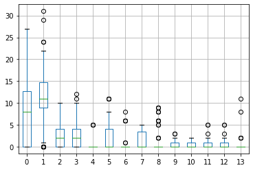

```python
# Box plot to check the outliers and spread of training input data

X_train_df.boxplot()
```

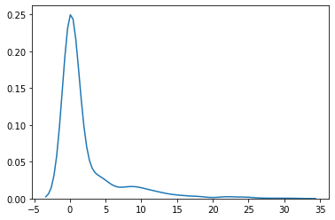

```python
# Density plot for complete training input data

sns.distplot(X_train_df, hist = False)
```

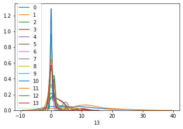

```python
# Density plots for each column in training input dataframe

for i in X_train_df:
    sns.distplot(X_train_df[i], hist = False, label = i)
```

Data seem need normalizing.

```python
# Normalizing training input data

normalized_X_train_df=(X_train_df-X_train_df.mean())/X_train_df.std()
```

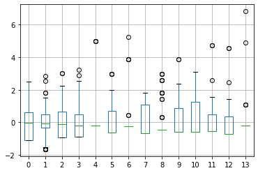

```python
# Box plot to check the outliers and spread of training input data

normalized_X_train_df.boxplot()
```

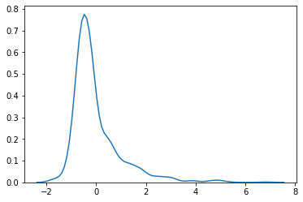

```python
# Density plot for complete training input data

sns.distplot(normalized_X_train_df, hist = False)
```

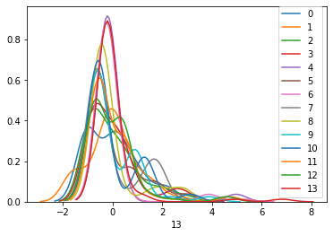

```python
# Density plots for each column in training input dataframe

for i in normalized_X_train_df:
    sns.distplot(normalized_X_train_df[i], hist = False, label = i)
```

Data seem normalized well and ready to be used further.

```python
# Checking statistical summary of normalized training input data

normalized_X_train_df.describe()
```

|  | 0 | 1 | 2 | 3 | 4 | 5 | 6 | 7 | 8 | 9 | 10 | 11 | 12 | 13 |
| --- | --- | --- | --- | --- | --- | --- | --- | --- | --- | --- | --- | --- | --- | --- |
| count | 7.800000e+01 | 7.800000e+01 | 7.800000e+01 | 7.800000e+01 | 7.800000e+01 | 7.800000e+01 | 7.800000e+01 | 7.800000e+01 | 7.800000e+01 | 7.800000e+01 | 78.000000 | 7.800000e+01 | 7.800000e+01 | 7.800000e+01 |
| mean | -4.270089e-17 | -3.985416e-17 | 8.824850e-17 | 2.846726e-17 | -7.187982e-17 | -3.985416e-17 | 1.138690e-17 | 1.138690e-17 | -5.266443e-17 | 1.138690e-17 | 0.000000 | -3.985416e-17 | -2.562053e-17 | -4.341257e-17 |
| std | 1.000000e+00 | 1.000000e+00 | 1.000000e+00 | 1.000000e+00 | 1.000000e+00 | 1.000000e+00 | 1.000000e+00 | 1.000000e+00 | 1.000000e+00 | 1.000000e+00 | 1.000000 | 1.000000e+00 | 1.000000e+00 | 1.000000e+00 |
| min | -1.071101e+00 | -1.644440e+00 | -9.050471e-01 | -8.617254e-01 | -1.987138e-01 | -6.163302e-01 | -2.460111e-01 | -6.428617e-01 | -4.426729e-01 | -5.922105e-01 | -0.567754 | -5.534807e-01 | -6.874615e-01 | -2.045854e-01 |
| 25% | -1.071101e+00 | -3.415089e-01 | -9.050471e-01 | -8.617254e-01 | -1.987138e-01 | -6.163302e-01 | -2.460111e-01 | -6.428617e-01 | -4.426729e-01 | -5.922105e-01 | -0.567754 | -5.534807e-01 | -6.874615e-01 | -2.045854e-01 |
| 50% | -1.188227e-02 | -5.196875e-02 | -1.206729e-01 | -1.793439e-01 | -1.987138e-01 | -6.163302e-01 | -2.460111e-01 | -6.428617e-01 | -4.426729e-01 | -5.922105e-01 | -0.567754 | -5.534807e-01 | -6.874615e-01 | -2.045854e-01 |
| 75% | 6.170291e-01 | 4.909191e-01 | 6.637012e-01 | 5.030377e-01 | -1.987138e-01 | 6.917992e-01 | -2.460111e-01 | 1.077739e+00 | -4.426729e-01 | 8.978676e-01 | 1.277446 | 4.994826e-01 | 3.639502e-01 | -2.045854e-01 |
| max | 2.503763e+00 | 2.843433e+00 | 3.016824e+00 | 3.232564e+00 | 4.967845e+00 | 2.981026e+00 | 5.236523e+00 | 1.815139e+00 | 2.972232e+00 | 3.878024e+00 | 3.122646 | 4.711336e+00 | 4.569597e+00 | 6.816785e+00 |

```python
# Convert dataframes into arrays

X_train_act = np.asarray(normalized_X_train_df)
y_train_act = df_train.iloc[:, 14:].values
print("Shape of training input data: ", X_train_act.shape)
print("Shape of training output data: ", y_train_act.shape)
```

```
Shape of training input data:  (78, 14)
Shape of training output data:  (78, 26)
```

### Load and Preprocess Test Data

```python
# Load Test Dataset

df_test = pd.read_excel("MFCR_Raw_Dataset.xlsx", sheet_name = "MFCR_Test", header = None)
print("Shape of df_test: ",df_test.shape)
print()
df_test.head()
```

```
Shape of df_test:  (78, 40)
```

|  | 0 | 1 | 2 | 3 | 4 | 5 | 6 | 7 | 8 | 9 | ... | 30 | 31 | 32 | 33 | 34 | 35 | 36 | 37 | 38 | 39 |
| --- | --- | --- | --- | --- | --- | --- | --- | --- | --- | --- | --- | --- | --- | --- | --- | --- | --- | --- | --- | --- | --- |
| 0 | 7 | 0 | 0 | 0 | 0 | 0 | 0 | 0 | 0 | 0 | ... | 0 | 0 | 0 | 0 | 0 | 0 | 0 | 0 | 0 | 0 |
| 1 | 7 | 0 | 0 | 0 | 0 | 0 | 0 | 0 | 0 | 0 | ... | 0 | 0 | 0 | 0 | 0 | 0 | 0 | 0 | 0 | 0 |
| 2 | 6 | 5 | 0 | 6 | 0 | 0 | 9 | 0 | 0 | 0 | ... | 0 | 0 | 0 | 0 | 0 | 0 | 0 | 0 | 0 | 0 |
| 3 | 27 | 14 | 2 | 2 | 0 | 8 | 0 | 5 | 0 | 2 | ... | 0 | 0 | 0 | 0 | 0 | 0 | 0 | 0 | 0 | 0 |
| 4 | 27 | 12 | 2 | 2 | 0 | 8 | 0 | 5 | 0 | 2 | ... | 0 | 0 | 0 | 0 | 0 | 0 | 0 | 0 | 0 | 0 |

5 rows × 40 columns

```python
# Separating input data from output data

X_test_df = df_test.drop(df_test.iloc[:, 14:], axis = 1)
X_test_df.head()
```

|  | 0 | 1 | 2 | 3 | 4 | 5 | 6 | 7 | 8 | 9 | 10 | 11 | 12 | 13 |
| --- | --- | --- | --- | --- | --- | --- | --- | --- | --- | --- | --- | --- | --- | --- |
| 0 | 7 | 0 | 0 | 0 | 0 | 0 | 0 | 0 | 0 | 0 | 0 | 0 | 0 | 13 |
| 1 | 7 | 0 | 0 | 0 | 0 | 0 | 0 | 0 | 0 | 0 | 0 | 0 | 0 | 11 |
| 2 | 6 | 5 | 0 | 6 | 0 | 0 | 9 | 0 | 0 | 0 | 1 | 0 | 0 | 0 |
| 3 | 27 | 14 | 2 | 2 | 0 | 8 | 0 | 5 | 0 | 2 | 0 | 0 | 2 | 0 |
| 4 | 27 | 12 | 2 | 2 | 0 | 8 | 0 | 5 | 0 | 2 | 0 | 0 | 2 | 0 |

```python
# Checking statistical summary of test input data

X_test_df.describe()
```

|  | 0 | 1 | 2 | 3 | 4 | 5 | 6 | 7 | 8 | 9 | 10 | 11 | 12 | 13 |
| --- | --- | --- | --- | --- | --- | --- | --- | --- | --- | --- | --- | --- | --- | --- |
| count | 78.000000 | 78.000000 | 78.000000 | 78.000000 | 78.000000 | 78.000000 | 78.000000 | 78.000000 | 78.000000 | 78.000000 | 78.000000 | 78.000000 | 78.000000 | 78.000000 |
| mean | 8.051282 | 11.128205 | 2.256410 | 2.974359 | 0.307692 | 2.128205 | 0.346154 | 1.435897 | 0.858974 | 0.410256 | 0.217949 | 0.538462 | 0.769231 | 0.307692 |
| std | 7.730690 | 6.941984 | 2.746596 | 3.314566 | 1.389270 | 3.192357 | 1.527471 | 2.201474 | 2.372594 | 0.672964 | 0.415525 | 1.089410 | 1.103984 | 1.915810 |
| min | 0.000000 | 0.000000 | 0.000000 | 0.000000 | 0.000000 | 0.000000 | 0.000000 | 0.000000 | 0.000000 | 0.000000 | 0.000000 | 0.000000 | 0.000000 | 0.000000 |
| 25% | 0.000000 | 6.250000 | 0.000000 | 0.000000 | 0.000000 | 0.000000 | 0.000000 | 0.000000 | 0.000000 | 0.000000 | 0.000000 | 0.000000 | 0.000000 | 0.000000 |
| 50% | 8.000000 | 11.500000 | 1.000000 | 2.000000 | 0.000000 | 0.000000 | 0.000000 | 0.000000 | 0.000000 | 0.000000 | 0.000000 | 0.000000 | 0.500000 | 0.000000 |
| 75% | 12.750000 | 14.000000 | 4.000000 | 4.750000 | 0.000000 | 4.000000 | 0.000000 | 4.000000 | 0.000000 | 1.000000 | 0.000000 | 1.000000 | 1.000000 | 0.000000 |
| max | 27.000000 | 31.000000 | 12.000000 | 13.000000 | 9.000000 | 11.000000 | 9.000000 | 8.000000 | 9.000000 | 3.000000 | 1.000000 | 6.000000 | 6.000000 | 13.000000 |

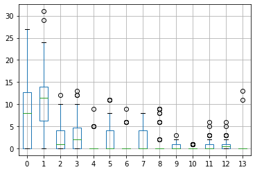

```python
# Box plot to check the outliers and spread of test input data

X_test_df.boxplot()
```

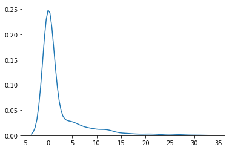

```python
# Density plot for complete test input data

sns.distplot(X_test_df, hist = False)
```

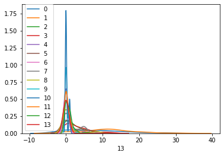

```python
# Density plots for each column in test input dataframe

for i in X_test_df:
    sns.distplot(X_test_df[i], hist = False, label = i)
```

Data seem need normalizing.

```python
# Normalize test input data

normalized_X_test_df=(X_test_df-X_test_df.mean())/X_test_df.std()
```

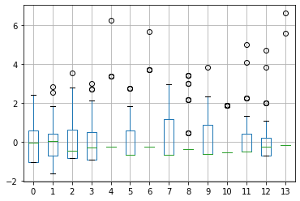

```python
# Box plot to check the outliers and spread of test input data

normalized_X_test_df.boxplot()
```

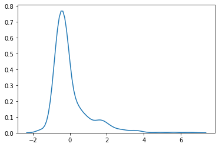

```python
# Density plot for complete test input data

sns.distplot(normalized_X_test_df, hist = False)
```

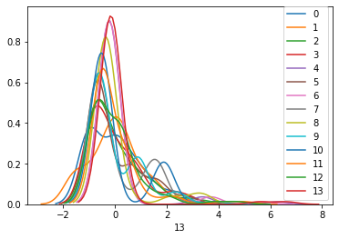

```python
# Density plots for each column in training input dataframe

for i in normalized_X_test_df:
    sns.distplot(normalized_X_test_df[i], hist = False, label = i)
```

Data seem normalized well and ready to be used further.

```python
# Convert dataframes into arrays

X_test_act = np.asarray(normalized_X_test_df)
y_test_act = df_test.iloc[:, 14:].values
print("Shape of test input data: ", X_test_act.shape)
print("Shape of test output data: ", y_test_act.shape)
```

```
Shape of test input data:  (78, 14)
Shape of test output data:  (78, 26)
```

### Finding optimized parameter

We'll use grid search method to find optimized parameters for SVM.

```python
# Preparing target labels as multiclass labels

count = 1
cls = 1
Y_class = []
for i in range (104):
    if count == 4:
        count = 1
        cls +=1
    else:
        Y_class.append(cls)
        count += 1

Y_class_arr = np.asarray(Y_class)
```

```python
# Hyper-parameter space to optimize SVM

# Parameters options
parameter_space = {'kernel': ['linear', 'rbf'], 'gamma': [0.001, 0.01, 0.1, 1], 'C': [0.001, 0.01, 0.1, 1, 10]}

# Cross-validation split
cv = StratifiedShuffleSplit(n_splits = 14, test_size=0.6, random_state = 1)

# Finding best parameters
clf = GridSearchCV(SVC(),parameter_space, cv = cv)
clf.fit(X_train_act, Y_class_arr)
print(clf.best_params_)
```

```
{'C': 10, 'gamma': 0.001, 'kernel': 'linear'}
```

### Building and Evaluating Model

```python
# Training the model using best parameters
clf.fit(X_train_act, Y_class_arr)

# Predicting target labels on test data
y_pred = clf.predict(X_test_act)
y_test = Y_class_arr
```

```python
# Best score on training dataset

clf.score(X_train_act, Y_class_arr)
```

```
1.0
```

```python
# Best score on testing dataset

clf.score(X_test_act, Y_class_arr)
```

```
0.8974358974358975
```

```
Accuracy Score: 0.8974358974358975
```

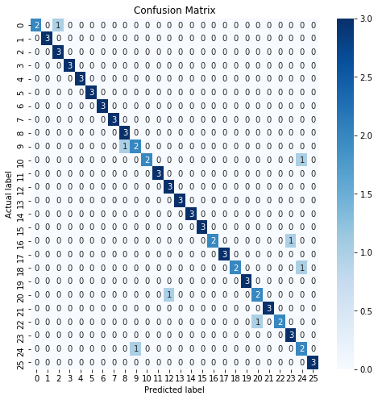

```python
# Printing Accuracy Score
print ('Accuracy Score: {}'.format(accuracy_score(y_test, y_pred)))

# Confusion Matrix
results = confusion_matrix(y_test, y_pred)
plt.figure(figsize=(8,8))
sns.heatmap(results, annot=True, fmt="d", cmap = 'Blues')
plt.title('Confusion Matrix')
plt.ylabel('Actual label')
plt.xlabel('Predicted label')
```

```python
# Classification Report

print ('Classification Report: ')
print (classification_report(y_test, y_pred))
```

```
Classification Report:
              precision    recall  f1-score   support

           1       1.00      0.67      0.80         3
           2       1.00      1.00      1.00         3
           3       0.75      1.00      0.86         3
           4       1.00      1.00      1.00         3
           5       1.00      1.00      1.00         3
           6       1.00      1.00      1.00         3
           7       1.00      1.00      1.00         3
           8       1.00      1.00      1.00         3
           9       0.75      1.00      0.86         3
          10       0.67      0.67      0.67         3
          11       1.00      0.67      0.80         3
          12       1.00      1.00      1.00         3
```

[output cut: 18 more lines]

### Conclusion

There is still scope of further optimizing SVM model using randomized grid search option.